# Lab7_McMullen

Jared McMullen

11/11/2021

# GSE 524 Lab 7

## The Data

```r
# Import the data set

ha <- read_csv("https://www.dropbox.com/s/aohbr6yb9ifmc8w/heart_attack.csv?dl=1")
ha <- ha %>%
  mutate(
    sex = as.factor(sex),
    restecg  = as.factor(restecg),
    cp = as.factor(cp),
    output = factor(output)
  )
datatable(ha)
```

|  | age | sex | cp | trtbps | chol | restecg | thalach | output |
| --- | --- | --- | --- | --- | --- | --- | --- | --- |
| 1 | 63 | 1 | 3 | 145 | 233 | 0 | 150 | 1 |
| 2 | 37 | 1 | 2 | 130 | 250 | 1 | 187 | 1 |
| 3 | 56 | 1 | 1 | 120 | 236 | 1 | 178 | 1 |
| 4 | 57 | 0 | 0 | 120 | 354 | 1 | 163 | 1 |
| 5 | 57 | 1 | 0 | 140 | 192 | 1 | 148 | 1 |
| 6 | 56 | 0 | 1 | 140 | 294 | 0 | 153 | 1 |
| 7 | 44 | 1 | 1 | 120 | 263 | 1 | 173 | 1 |
| 8 | 52 | 1 | 2 | 172 | 199 | 1 | 162 | 1 |
| 9 | 57 | 1 | 2 | 150 | 168 | 1 | 174 | 1 |
| 10 | 54 | 1 | 0 | 140 | 239 | 1 | 160 | 1 |

[output cut: 263 more lines]

# Part One: Fitting Models

Finding the correct variables with visualizations

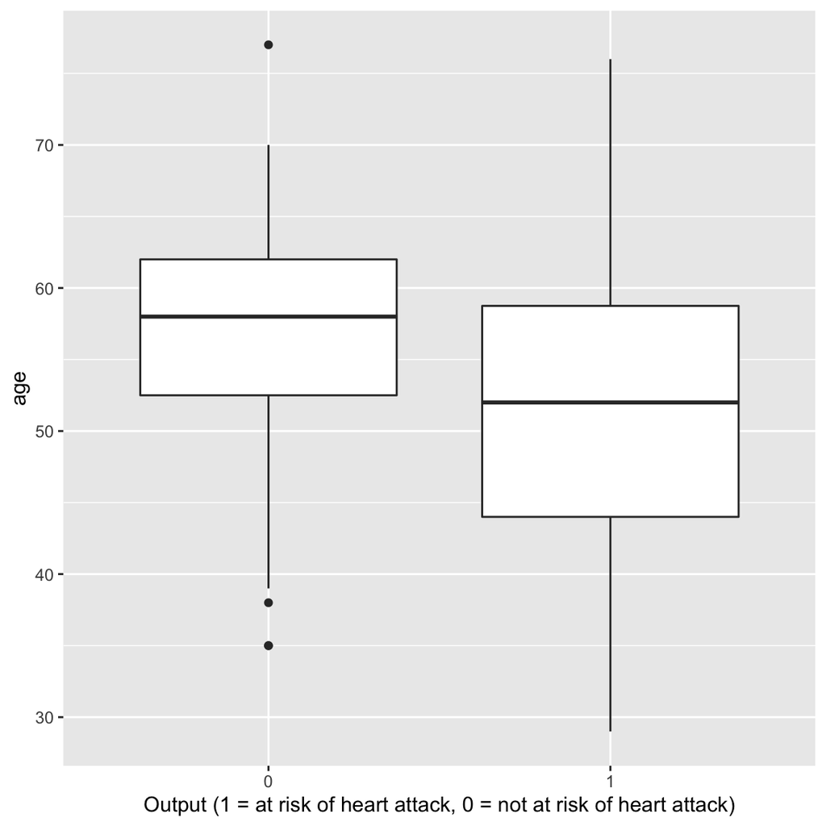

```r
ha %>%
  ggplot(aes(y= age, x = as.factor(output))) +
  geom_boxplot() +
  xlab("Output (1 = at risk of heart attack, 0 = not at risk of heart attack)")
```

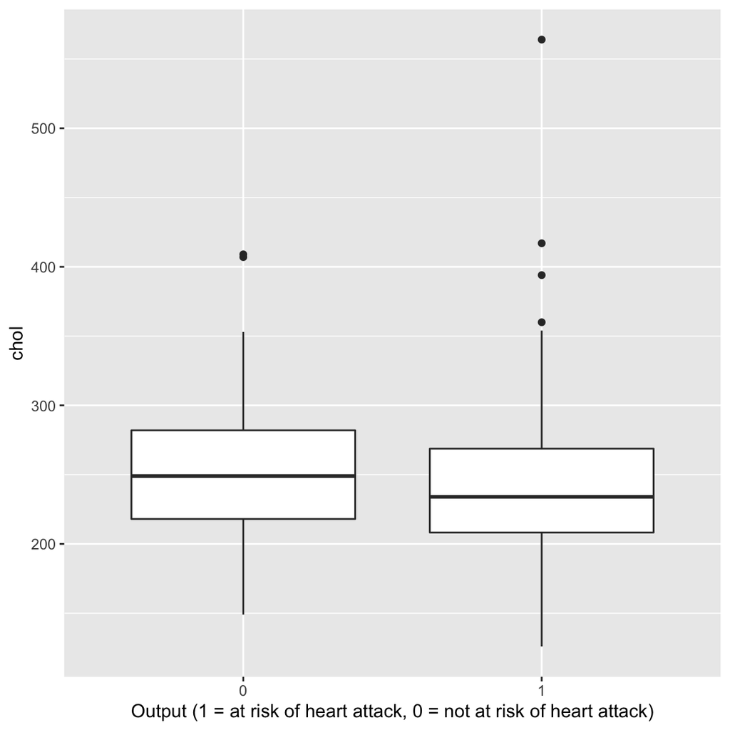

```r
ha %>%
  ggplot(aes(y= chol, x = as.factor(output))) +
  geom_boxplot() +
  xlab("Output (1 = at risk of heart attack, 0 = not at risk of heart attack)")
```

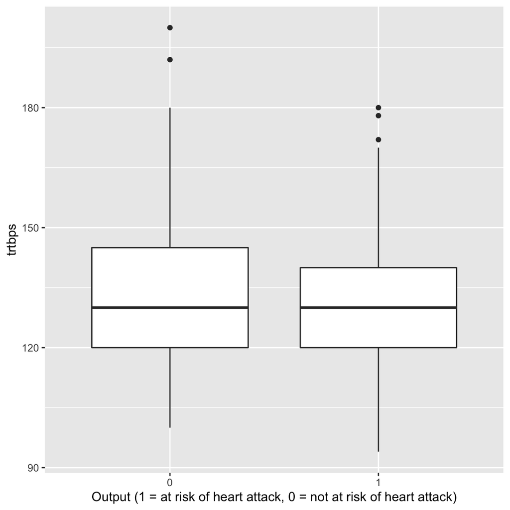

```r
ha %>%
  ggplot(aes(y= trtbps, x = as.factor(output))) +
  geom_boxplot() +
  xlab("Output (1 = at risk of heart attack, 0 = not at risk of heart attack)")
```

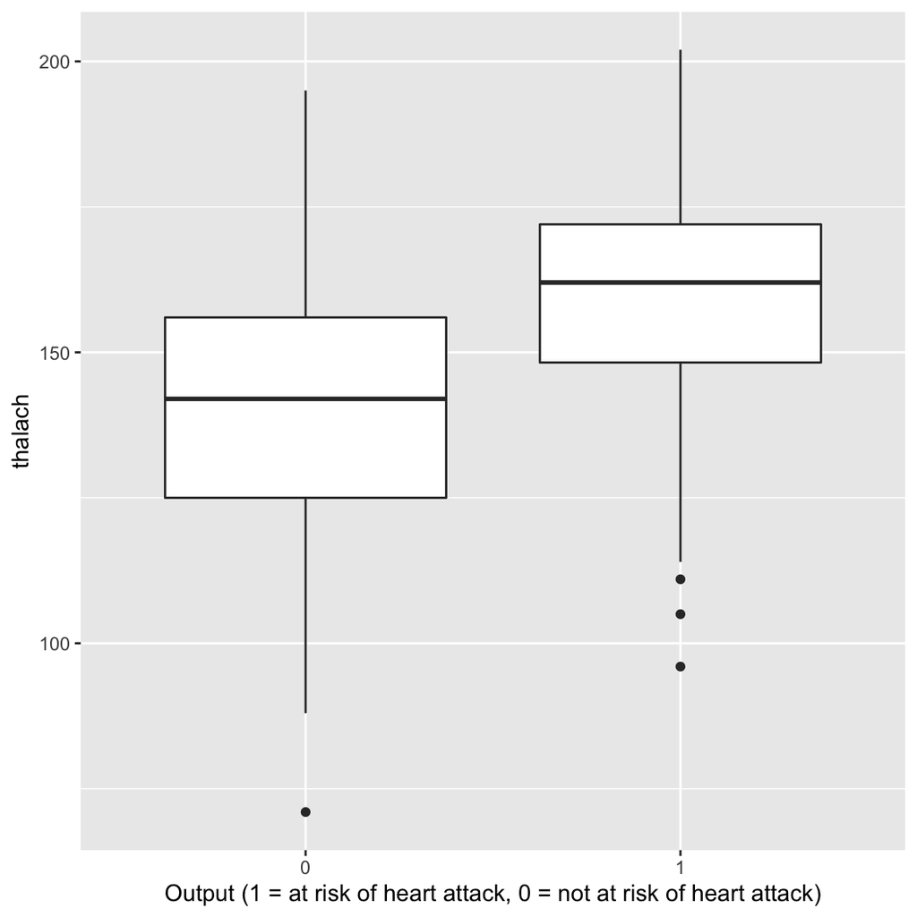

```r
ha %>%
  ggplot(aes(y= thalach, x = as.factor(output))) +
  geom_boxplot() +
  xlab("Output (1 = at risk of heart attack, 0 = not at risk of heart attack)")
```

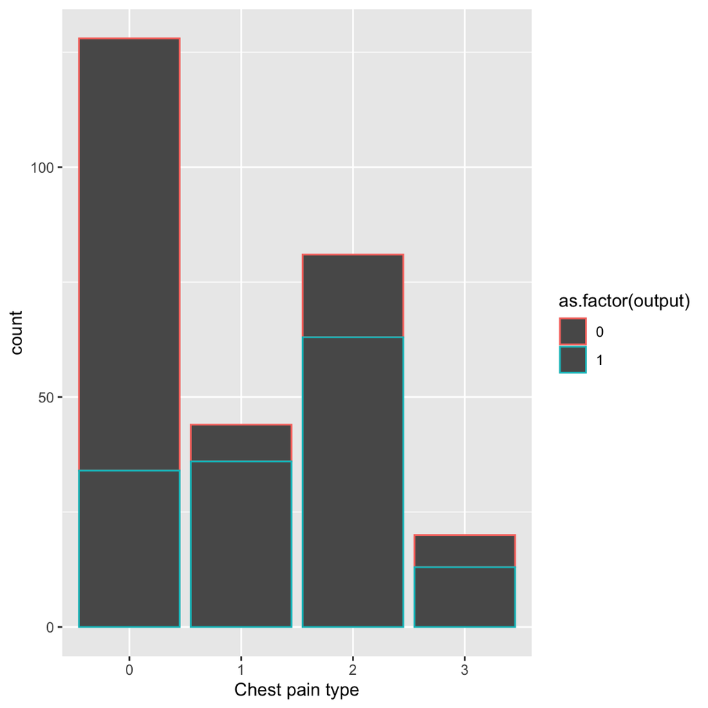

```r
ha %>%
  ggplot(aes(x= cp, color = as.factor(output))) +
  geom_bar() +
  xlab("Chest pain type")
```

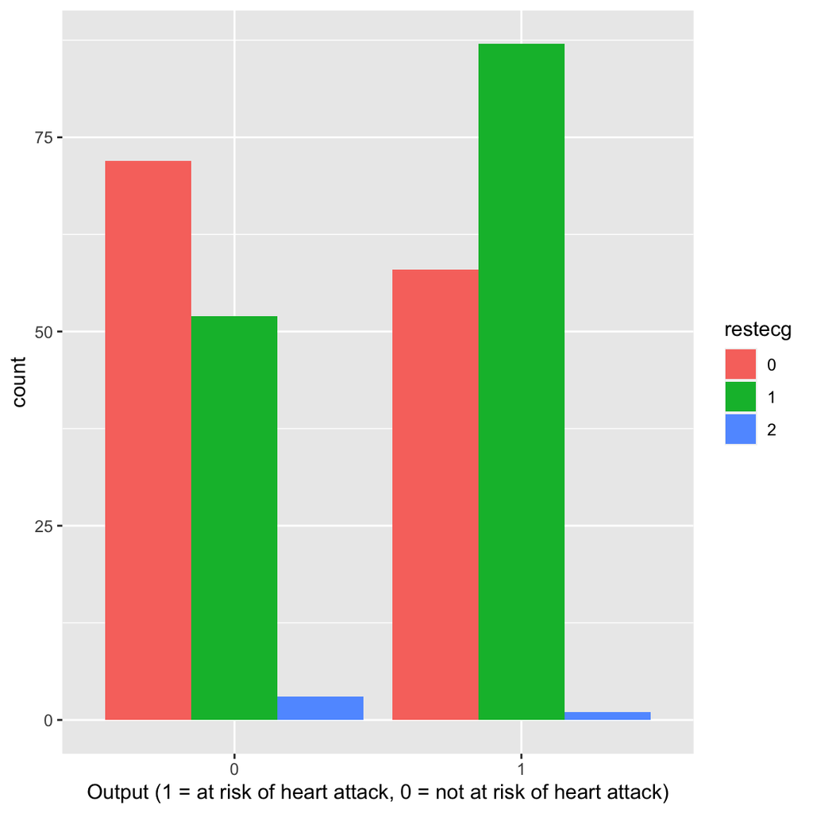

```r
ha %>% ggplot(aes(as.factor(output), ..count..)) + geom_bar(aes(fill = restecg), position = "dodge")+
  xlab("Output (1 = at risk of heart attack, 0 = not at risk of heart attack)")
```

The process will begin by splitting the data into test and training datasets.

```r
ha_split <- ha %>% initial_split()
# Save test and training as separate datasets
ha_test <- ha_split %>% testing()
ha_train <- ha_split %>% training()
# Check what happened
dim(ha_test)
```

```
## [1] 69  8
```

```r
dim(ha_train)
```

```
## [1] 204   8
```

# Q1: KKNN

In this part, we will test models using the KNN

```r
#Creating Model
knn_mod <- nearest_neighbor(neighbors = 7) %>%
  set_engine("kknn") %>%
  set_mode("classification")

# add recipe
knn_rec <- recipe(output ~ age + sex + cp + chol + restecg + thalach, data = ha_train) %>%
  step_dummy(sex)  %>%
  step_dummy(cp) %>%
  step_dummy(restecg) %>%
  step_normalize(all_numeric())

# Add workflow
knn_wflow <- workflow() %>%
  add_recipe(knn_rec) %>%
  add_model(knn_mod)

# Fit the model
knn_fit <- knn_wflow %>%
  fit(ha_train)

knn_fit %>% pull_workflow_fit()
```

```
## parsnip model object
##
## Fit time:  13ms
##
## Call:
## kknn::train.kknn(formula = ..y ~ ., data = data, ks = min_rows(7,     data, 5))
##
## Type of response variable: nominal
## Minimal misclassification: 0.3382353
## Best kernel: optimal
## Best k: 7
```

```r
#Roc calculation
pred <- knn_fit %>% predict(ha_test, type = "prob")

ha_test <- ha_test %>%
  mutate(
    predicted = pred$.pred_0
  )
roc_auc(ha_test, output, predicted)
```

```
## # A tibble: 1 × 3
##   .metric .estimator .estimate
##   <chr>   <chr>          <dbl>
## 1 roc_auc binary         0.821
```

```r
#Confusion Matrix
pred <- knn_fit %>% predict(ha_test)

ha_test1 <- ha_test %>%
  mutate(
    predicted = pred$.pred_class
  )
ha_test1 %>% count(output, predicted)
```

```
## # A tibble: 4 × 3
##   output predicted     n
##   <fct>  <fct>     <int>
## 1 0      0            30
## 2 0      1             7
## 3 1      0             8
## 4 1      1            24
```

From testing the model and receiving multiple roc.auc values, I was able to conclude that taking out trtbps as one of the predictor variables made the area value higher, alluding to a better model overall.

# Q2: Logistic Regression

```r
log_mod <- logistic_reg() %>%
  set_mode("classification") %>%
  set_engine("glm")

#add recipe
log_rec <- recipe(output ~ age + sex + cp + chol + restecg + thalach, data = ha_train) %>%
  step_dummy(sex)  %>%
  step_dummy(cp) %>%
  step_dummy(restecg) %>%
  step_normalize(all_numeric())

# Add workflow
log_wflow <- workflow() %>%
  add_recipe(log_rec) %>%
  add_model(log_mod)

#fit the model
log_fit <- log_wflow%>%
  fit(ha_train)

#Roc calculation
pred <- log_fit %>% predict(ha_test, type = "prob")
ha_test2 <- ha_test %>%
  mutate(
    predicted = pred$.pred_0
  )
roc_auc(ha_test2, output, predicted)
```

```
## # A tibble: 1 × 3
##   .metric .estimator .estimate
##   <chr>   <chr>          <dbl>
## 1 roc_auc binary         0.890
```

```r
#Confusion Matrix
pred <- log_fit %>% predict(ha_test)

ha_test3 <- ha_test %>%
  mutate(
    predicted = pred$.pred_class
  )
ha_test3 %>% count(output, predicted)
```

```
## # A tibble: 4 × 3
##   output predicted     n
##   <fct>  <fct>     <int>
## 1 0      0            30
## 2 0      1             7
## 3 1      0             5
## 4 1      1            27
```

```r
ha_cvs <- vfold_cv(ha, v = 5)

#Log
log_wflow %>%
  fit_resamples(resamples = ha_cvs) %>%
  collect_metrics
```

```
## # A tibble: 2 × 6
##   .metric  .estimator  mean     n std_err .config
##   <chr>    <chr>      <dbl> <int>   <dbl> <chr>
## 1 accuracy binary     0.755     5  0.0282 Preprocessor1_Model1
## 2 roc_auc  binary     0.849     5  0.0194 Preprocessor1_Model1
```

```r
#KNN
knn_wflow %>%
  fit_resamples(resamples = ha_cvs) %>%
  collect_metrics
```

```
## # A tibble: 2 × 6
##   .metric  .estimator  mean     n std_err .config
##   <chr>    <chr>      <dbl> <int>   <dbl> <chr>
## 1 accuracy binary     0.721     5  0.0185 Preprocessor1_Model1
## 2 roc_auc  binary     0.809     5  0.0170 Preprocessor1_Model1
```

# Q3: Interpretation

Based on an analysis of both models, It appears that age, sex , cp , chol , restecg and thalach all had a positive impact on predicting values given a training set. The only variables that had a negative influence was trtbps, which is the resting blood pressure of an individual.

# Q4: ROC Curve

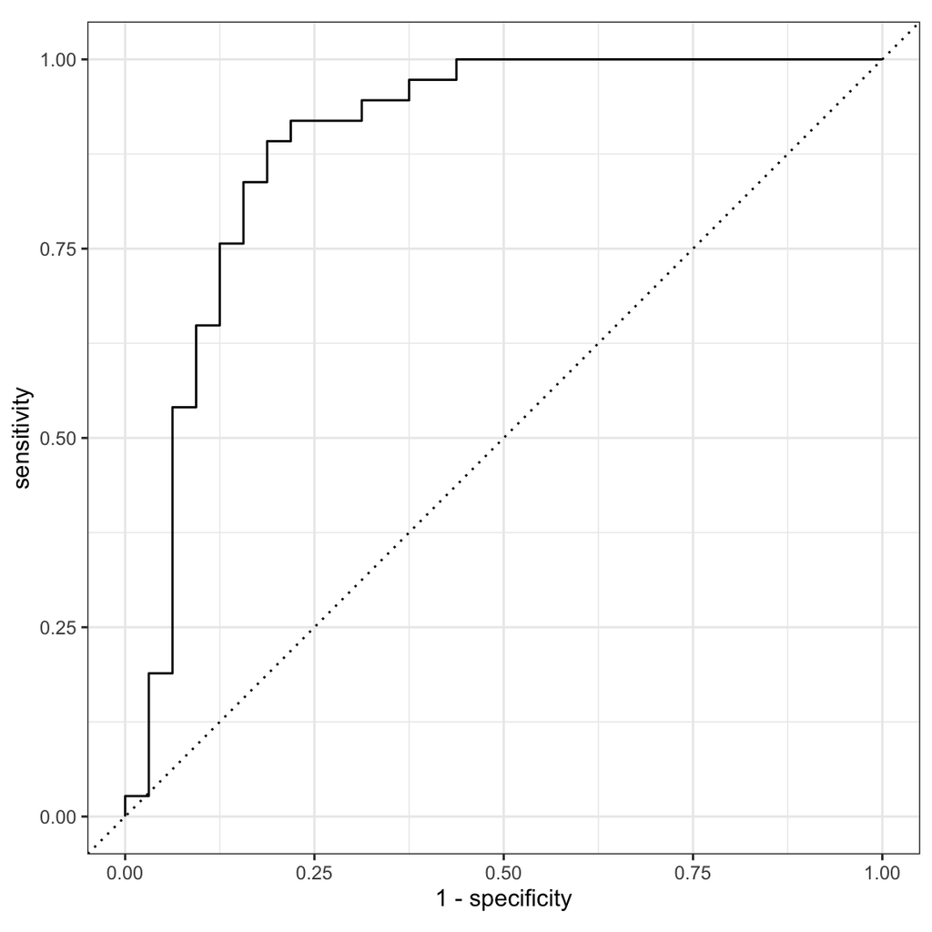

```r
# Logistic Model
ha_test2 %>%
  roc_curve(truth = output, predicted) %>%
  autoplot()
```

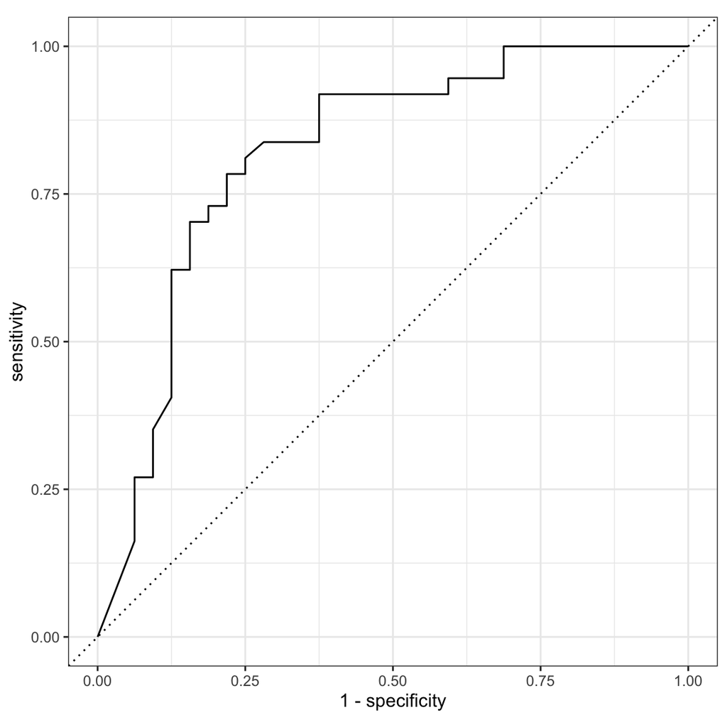

```r
# KNN Model
ha_test %>%
  roc_curve(truth = output, predicted) %>%
  autoplot()
```